# R Notebook

# Instructions

You work for Motor Trend, a magazine about the automobile industry. Looking at a data set of a collection of cars, they are interested in exploring the relationship between a set of variables and miles per gallon (MPG) (outcome). They are particularly interested in the following two questions:

```
“Is an automatic or manual transmission better for MPG”

"Quantify the MPG difference between automatic and manual transmissions"
```

# Review criteria

Peer Grading

```
The criteria that your classmates will use to evaluate and grade your work are shown below.
Each criteria is binary: (1 point = criteria met acceptably; 0 points = criteria not met acceptably)
```

Criteria

```
Did the student interpret the coefficients correctly?
Did the student do some exploratory data analyses?
Did the student fit multiple models and detail their strategy for model selection?
Did the student answer the questions of interest or detail why the question(s) is (are) not answerable?
Did the student do a residual plot and some diagnostics?
Did the student **quantify the uncertainty** in their conclusions and/or perform an **inference** correctly?
Was the report brief (about 2 pages long) for the main body of the report and no longer than 5 with supporting appendix of figures?
Did the report include an executive summary?
Was the report done in Rmd (knitr)?
```

# Question

Take the mtcars data set and write up an analysis to answer their question using regression models and exploratory data analyses.

Your report must be:

Written as a **PDF printout** of a compiled (using knitr) R markdown document.

Brief. Roughly the equivalent of 2 pages or less for the main text. Supporting figures in an appendix can be included up to 5 total pages including the 2 for the main report. The appendix can only include figures.

Include a first paragraph **executive summary**.

Upload your **PDF** by clicking the Upload button below the text box.

# Executive Summary

This report summarizes the relationship between MPG and transmission types in the mtcars dataset. The result of the statistical analysis using linear regression models is that a switch from automatic to manual transmission should lead to an **increase in miles per gallon**.

## Data: mtcars

Change format of variable ‘am’ to factor and review structure of ‘mtcars’.

```r
str(mtcars)
```

```
Classes ‘data.table’ and 'data.frame':  32 obs. of  11 variables:
 $ mpg : num  21 21 22.8 21.4 18.7 18.1 14.3 24.4 22.8 19.2 ...
 $ cyl : num  6 6 4 6 8 6 8 4 4 6 ...
 $ disp: num  160 160 108 258 360 ...
 $ hp  : num  110 110 93 110 175 105 245 62 95 123 ...
 $ drat: num  3.9 3.9 3.85 3.08 3.15 2.76 3.21 3.69 3.92 3.92 ...
 $ wt  : num  2.62 2.88 2.32 3.21 3.44 ...
 $ qsec: num  16.5 17 18.6 19.4 17 ...
 $ vs  : num  0 0 1 1 0 1 0 1 1 1 ...
 $ am  : Factor w/ 2 levels "auto","man": 2 2 2 1 1 1 1 1 1 1 ...
 $ gear: num  4 4 4 3 3 3 3 4 4 4 ...
 $ carb: num  4 4 1 1 2 1 4 2 2 4 ...
 - attr(*, ".internal.selfref")=<externalptr>
```

Transmission is represented by a factor variable ‘am’ where 0 stands for automatic and 1 represents manual.

## Scatterplots

### mpg ~ disp

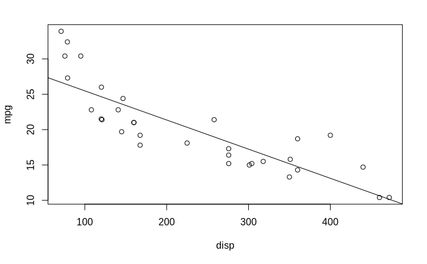

```r
plot(disp, mpg)
abline(lm(mpg ~ disp))
```

### Scatterplot mpg ~ wt

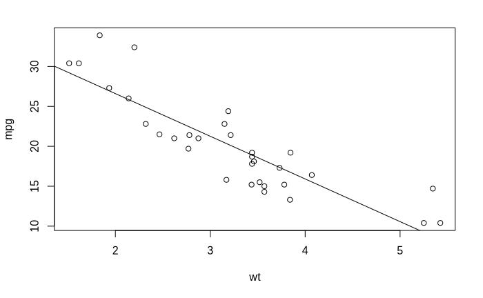

```r
plot(wt, mpg)
abline(lm(mpg ~ wt, data = mtcars))
```

## Fit linear model with reasonable regressors

Fit a model including all regressors that seem reasonable, i.e. are expected to have an effect on ‘miles per gallon’:

```r
summary(fit_reas)
```

```
Call:
lm(formula = mpg ~ disp + wt + am - 1)

Residuals:
    Min      1Q  Median      3Q     Max
-10.041  -3.274   1.184   5.340  10.993

Coefficients:
     Estimate Std. Error t value Pr(>|t|)
disp -0.06092    0.01876  -3.247  0.00294 **
wt    8.83768    1.53585   5.754 3.13e-06 ***
am   11.82922    2.23605   5.290 1.13e-05 ***
---
Signif. codes:  0 ‘***’ 0.001 ‘**’ 0.01 ‘*’ 0.05 ‘.’ 0.1 ‘ ’ 1

Residual standard error: 6.578 on 29 degrees of freedom
Multiple R-squared:  0.9106,    Adjusted R-squared:  0.9014
F-statistic: 98.51 on 3 and 29 DF,  p-value: 2.61e-15
```

Switching from automatic to manual increases miles per gallons.

Extremely low **p-value** shows that result is **statistically significant**.

### Check Residuals’ Plot

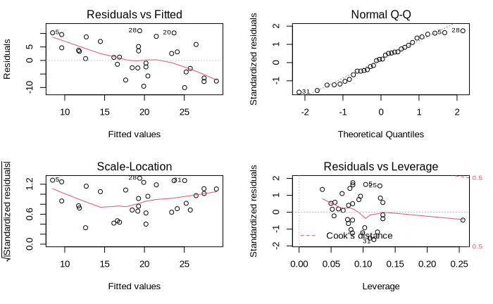

```r
par(mfrow = c(2,2))
plot(fit_reas)
```

# Only ‘am’ as Regressor

```r
fit_am <- lm(mpg ~ am)
summary(fit_am)
```

```
Call:
lm(formula = mpg ~ am)

Residuals:
    Min      1Q  Median      3Q     Max
-9.3923 -3.0923 -0.2974  3.2439  9.5077

Coefficients:
            Estimate Std. Error t value Pr(>|t|)
(Intercept)   17.147      1.125  15.247 1.13e-15 ***
am             7.245      1.764   4.106 0.000285 ***
---
Signif. codes:  0 ‘***’ 0.001 ‘**’ 0.01 ‘*’ 0.05 ‘.’ 0.1 ‘ ’ 1

Residual standard error: 4.902 on 30 degrees of freedom
Multiple R-squared:  0.3598,    Adjusted R-squared:  0.3385
F-statistic: 16.86 on 1 and 30 DF,  p-value: 0.000285
```

Result statistically significant as the p-value is far below 0.05.  
Going from ‘automatic’ to ‘manual’ the **miles per gallons increases**.

### Check Residuals’ Plot

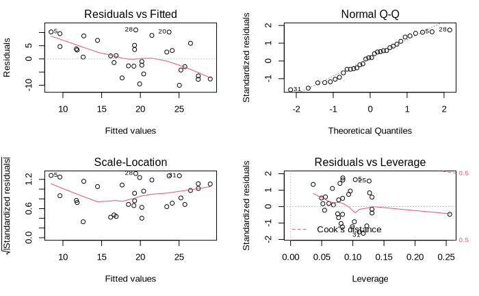

```r
par(mfrow = c(2,2))
plot(fit_reas)
```

# t-Test

```r
t.test(mpg ~ am, mtcars)
```

```
    Welch Two Sample t-test

data:  mpg by am
t = -3.7671, df = 18.332, p-value = 0.001374
alternative hypothesis: true difference in means between group auto and group man is not equal to 0
95 percent confidence interval:
 -11.280194  -3.209684
sample estimates:
mean in group auto  mean in group man
          17.14737           24.39231
```

The difference between the means is statistically significant considering the low p-value.